# Créer et Exploiter une Base de Données sous R

Jeudi 03 mai - Vendredi 04 mai

## Les Bases de Données et R

[figure not shown]

## Préparer sa session

[figure not shown]

## Trucs et astuces

- Eviter de changer votre répertoire de travail avec `setwd()`,  
  c.-à-d. démarrer R directement au bon endroit ou définir un "Projet" dans Rstudio.
- Ne pas utiliser le `.Rprofile` avec des options modifiant le comportant de R.
- Désactiver la conversion automatique des chaînes de caractères en facteurs `options(stringsAsFactors = FALSE)`.
- Ne pas utiliser `rm(list = ls())` pour "rafraichir" votre session.
- Ne pas sauvegarder/charger `.Rdata` en quittant/démarrant votre session R.

[figure not shown]

[figure not shown]

## Le *tidyverse*

## Qu'est-ce-que le *tidyverse* ?

Un ensemble d'outils basés sur une philosophie/grammaire commune.

```r
if (!"tidyverse"%in%rownames(installed.packages())) {
  install.packages("tidyverse")
}
library(tidyverse)
```

## Qu'est-ce-que le *tidyverse* ?

`library(tidyverse)` chargera les packages :

- [readr](http://readr.tidyverse.org), importation.
- [tibble](http://tibble.tidyverse.org), classe d'objet "tibble".
- [dplyr](http://dplyr.tidyverse.org), manipulation.
- [tidyr](http://tidyr.tidyverse.org), mise en forme.
- [ggplot2](http://ggplot2.tidyverse.org), visualisation.
- [purrr](http://purrr.tidyverse.org), programmation.

Ces packages représentent la base du *tidyverse* et sont en constante évolution.

```r
tidyverse_update()
```

## *tibble*

### comme un *data.frame*, mais en mieux !

[figure not shown]

## Pré-requis

```r
library(tidyverse)
```

```r
tidyverse_conflicts()
```

## Construire un *tibble*

```r
tibble(
  x = 1:5,
  y = 1,
  z = x ^ 2 + y
)
```

```
#> # A tibble: 5 x 3
#>       x     y     z
#>   <int> <dbl> <dbl>
#> 1     1  1.00  2.00
#> 2     2  1.00  5.00
#> 3     3  1.00 10.0
#> # ... with 2 more rows
```

```r
data.frame(
  x = 1:5,
  y = 1,
  z = x ^ 2 + y
)
```

```
#> Error in data.frame(x = 1:5, y = 1, z = x^2 + y): objet 'x' introuvable
```

## Construire un *tibble*

Et avec des noms de variables "exotiques" ?

```r
data.frame(`1`= 1:3)
```

```
#>   X1
#> 1  1
#> 2  2
#> 3  3
```

```r
tibble(
  `;)` = 1:5,
  `42` = "1",
  `€` = `;)` ^ 2 + as.numeric(`42`)
)
```

```
#> # A tibble: 5 x 3
#>    `;)` `42`    `€`
#>   <int> <chr> <dbl>
#> 1     1 1      2.00
#> 2     2 1      5.00
#> 3     3 1     10.0
#> # ... with 2 more rows
```

## Afficher un *data.frame*

Les méthodes `show()` et `print()` :

```r
as.data.frame(mtcars)
```

```
#>                      mpg cyl  disp  hp drat    wt  qsec vs am gear carb
#> Mazda RX4           21.0   6 160.0 110 3.90 2.620 16.46  0  1    4    4
#> Mazda RX4 Wag       21.0   6 160.0 110 3.90 2.875 17.02  0  1    4    4
#> Datsun 710          22.8   4 108.0  93 3.85 2.320 18.61  1  1    4    1
#> Hornet 4 Drive      21.4   6 258.0 110 3.08 3.215 19.44  1  0    3    1
#> Hornet Sportabout   18.7   8 360.0 175 3.15 3.440 17.02  0  0    3    2
#> Valiant             18.1   6 225.0 105 2.76 3.460 20.22  1  0    3    1
#> Duster 360          14.3   8 360.0 245 3.21 3.570 15.84  0  0    3    4
#> Merc 240D           24.4   4 146.7  62 3.69 3.190 20.00  1  0    4    2
#> Merc 230            22.8   4 140.8  95 3.92 3.150 22.90  1  0    4    2
#> Merc 280            19.2   6 167.6 123 3.92 3.440 18.30  1  0    4    4
#> Merc 280C           17.8   6 167.6 123 3.92 3.440 18.90  1  0    4    4
#> Merc 450SE          16.4   8 275.8 180 3.07 4.070 17.40  0  0    3    3
#> Merc 450SL          17.3   8 275.8 180 3.07 3.730 17.60  0  0    3    3
#> Merc 450SLC         15.2   8 275.8 180 3.07 3.780 18.00  0  0    3    3
#> Cadillac Fleetwood  10.4   8 472.0 205 2.93 5.250 17.98  0  0    3    4
#> Lincoln Continental 10.4   8 460.0 215 3.00 5.424 17.82  0  0    3    4
#> Chrysler Imperial   14.7   8 440.0 230 3.23 5.345 17.42  0  0    3    4
#> Fiat 128            32.4   4  78.7  66 4.08 2.200 19.47  1  1    4    1
#> Honda Civic         30.4   4  75.7  52 4.93 1.615 18.52  1  1    4    2
#> Toyota Corolla      33.9   4  71.1  65 4.22 1.835 19.90  1  1    4    1
#> Toyota Corona       21.5   4 120.1  97 3.70 2.465 20.01  1  0    3    1
#> Dodge Challenger    15.5   8 318.0 150 2.76 3.520 16.87  0  0    3    2
#> AMC Javelin         15.2   8 304.0 150 3.15 3.435 17.30  0  0    3    2
#> Camaro Z28          13.3   8 350.0 245 3.73 3.840 15.41  0  0    3    4
#> Pontiac Firebird    19.2   8 400.0 175 3.08 3.845 17.05  0  0    3    2
#> Fiat X1-9           27.3   4  79.0  66 4.08 1.935 18.90  1  1    4    1
#> Porsche 914-2       26.0   4 120.3  91 4.43 2.140 16.70  0  1    5    2
#> Lotus Europa        30.4   4  95.1 113 3.77 1.513 16.90  1  1    5    2
#> Ford Pantera L      15.8   8 351.0 264 4.22 3.170 14.50  0  1    5    4
#> Ferrari Dino        19.7   6 145.0 175 3.62 2.770 15.50  0  1    5    6
#> Maserati Bora       15.0   8 301.0 335 3.54 3.570 14.60  0  1    5    8
#> Volvo 142E          21.4   4 121.0 109 4.11 2.780 18.60  1  1    4    2
```

```r
print(as.data.frame(mtcars))
```

```
#>                      mpg cyl  disp  hp drat    wt  qsec vs am gear carb
#> Mazda RX4           21.0   6 160.0 110 3.90 2.620 16.46  0  1    4    4
#> Mazda RX4 Wag       21.0   6 160.0 110 3.90 2.875 17.02  0  1    4    4
#> Datsun 710          22.8   4 108.0  93 3.85 2.320 18.61  1  1    4    1
#> Hornet 4 Drive      21.4   6 258.0 110 3.08 3.215 19.44  1  0    3    1
#> Hornet Sportabout   18.7   8 360.0 175 3.15 3.440 17.02  0  0    3    2
#> Valiant             18.1   6 225.0 105 2.76 3.460 20.22  1  0    3    1
#> Duster 360          14.3   8 360.0 245 3.21 3.570 15.84  0  0    3    4
#> Merc 240D           24.4   4 146.7  62 3.69 3.190 20.00  1  0    4    2
#> Merc 230            22.8   4 140.8  95 3.92 3.150 22.90  1  0    4    2
#> Merc 280            19.2   6 167.6 123 3.92 3.440 18.30  1  0    4    4
#> Merc 280C           17.8   6 167.6 123 3.92 3.440 18.90  1  0    4    4
#> Merc 450SE          16.4   8 275.8 180 3.07 4.070 17.40  0  0    3    3
#> Merc 450SL          17.3   8 275.8 180 3.07 3.730 17.60  0  0    3    3
#> Merc 450SLC         15.2   8 275.8 180 3.07 3.780 18.00  0  0    3    3
#> Cadillac Fleetwood  10.4   8 472.0 205 2.93 5.250 17.98  0  0    3    4
#> Lincoln Continental 10.4   8 460.0 215 3.00 5.424 17.82  0  0    3    4
#> Chrysler Imperial   14.7   8 440.0 230 3.23 5.345 17.42  0  0    3    4
#> Fiat 128            32.4   4  78.7  66 4.08 2.200 19.47  1  1    4    1
#> Honda Civic         30.4   4  75.7  52 4.93 1.615 18.52  1  1    4    2
#> Toyota Corolla      33.9   4  71.1  65 4.22 1.835 19.90  1  1    4    1
#> Toyota Corona       21.5   4 120.1  97 3.70 2.465 20.01  1  0    3    1
#> Dodge Challenger    15.5   8 318.0 150 2.76 3.520 16.87  0  0    3    2
#> AMC Javelin         15.2   8 304.0 150 3.15 3.435 17.30  0  0    3    2
#> Camaro Z28          13.3   8 350.0 245 3.73 3.840 15.41  0  0    3    4
#> Pontiac Firebird    19.2   8 400.0 175 3.08 3.845 17.05  0  0    3    2
#> Fiat X1-9           27.3   4  79.0  66 4.08 1.935 18.90  1  1    4    1
#> Porsche 914-2       26.0   4 120.3  91 4.43 2.140 16.70  0  1    5    2
#> Lotus Europa        30.4   4  95.1 113 3.77 1.513 16.90  1  1    5    2
#> Ford Pantera L      15.8   8 351.0 264 4.22 3.170 14.50  0  1    5    4
#> Ferrari Dino        19.7   6 145.0 175 3.62 2.770 15.50  0  1    5    6
#> Maserati Bora       15.0   8 301.0 335 3.54 3.570 14.60  0  1    5    8
#> Volvo 142E          21.4   4 121.0 109 4.11 2.780 18.60  1  1    4    2
```

## Afficher un *tibble*

Les méthodes `show()` et `print()` :

```r
as_tibble(mtcars)
```

```
#> # A tibble: 32 x 11
#>     mpg   cyl  disp    hp  drat    wt  qsec    vs    am  gear  carb
#> * <dbl> <dbl> <dbl> <dbl> <dbl> <dbl> <dbl> <dbl> <dbl> <dbl> <dbl>
#> 1  21.0  6.00   160 110    3.90  2.62  16.5  0     1.00  4.00  4.00
#> 2  21.0  6.00   160 110    3.90  2.88  17.0  0     1.00  4.00  4.00
#> 3  22.8  4.00   108  93.0  3.85  2.32  18.6  1.00  1.00  4.00  1.00
#> # ... with 29 more rows
```

```r
print(as_tibble(mtcars))
```

```
#> # A tibble: 32 x 11
#>     mpg   cyl  disp    hp  drat    wt  qsec    vs    am  gear  carb
#> * <dbl> <dbl> <dbl> <dbl> <dbl> <dbl> <dbl> <dbl> <dbl> <dbl> <dbl>
#> 1  21.0  6.00   160 110    3.90  2.62  16.5  0     1.00  4.00  4.00
#> 2  21.0  6.00   160 110    3.90  2.88  17.0  0     1.00  4.00  4.00
#> 3  22.8  4.00   108  93.0  3.85  2.32  18.6  1.00  1.00  4.00  1.00
#> # ... with 29 more rows
```

## Afficher un *tibble*

La fonction `rownames_to_column()` (et `column_to_rownames()`) :

```r
as_tibble(rownames_to_column(mtcars))
```

```
#> # A tibble: 32 x 12
#>   rowname       mpg   cyl  disp    hp  drat    wt  qsec    vs    am  gear  carb
#>   <chr>       <dbl> <dbl> <dbl> <dbl> <dbl> <dbl> <dbl> <dbl> <dbl> <dbl> <dbl>
#> 1 Mazda RX4    21.0  6.00   160 110    3.90  2.62  16.5  0     1.00  4.00  4.00
#> 2 Mazda RX4 ~  21.0  6.00   160 110    3.90  2.88  17.0  0     1.00  4.00  4.00
#> 3 Datsun 710   22.8  4.00   108  93.0  3.85  2.32  18.6  1.00  1.00  4.00  1.00
#> # ... with 29 more rows
```

```r
print(as_tibble(rownames_to_column(mtcars)))
```

```
#> # A tibble: 32 x 12
#>   rowname       mpg   cyl  disp    hp  drat    wt  qsec    vs    am  gear  carb
#>   <chr>       <dbl> <dbl> <dbl> <dbl> <dbl> <dbl> <dbl> <dbl> <dbl> <dbl> <dbl>
#> 1 Mazda RX4    21.0  6.00   160 110    3.90  2.62  16.5  0     1.00  4.00  4.00
#> 2 Mazda RX4 ~  21.0  6.00   160 110    3.90  2.88  17.0  0     1.00  4.00  4.00
#> 3 Datsun 710   22.8  4.00   108  93.0  3.85  2.32  18.6  1.00  1.00  4.00  1.00
#> # ... with 29 more rows
```

## Afficher un *tibble* : les options

Changer les options d'affichages d'un *tibble* :

- via `options()`

```r
options(tibble.print_max = n, tibble.print_min = m, dplyr.print_min = p)
```

Afficher les `n` premières lignes, s'il y a plus de `m` ligneset sur `p` colonnes.

- via `print()`

```r
print(x = DF, n = n, width = p))
```

- dans Rstudio via `View()`

[figure not shown]

```r
View(mtcars)
```

## Sélectionner une variable : `$`, `[` et `[[`

```r
mtcars$mpg
```

```
#>  [1] 21.0 21.0 22.8 21.4 18.7 18.1 14.3 24.4 22.8 19.2 17.8 16.4 17.3 15.2 10.4
#> [16] 10.4 14.7 32.4 30.4 33.9 21.5 15.5 15.2 13.3 19.2 27.3 26.0 30.4 15.8 19.7
#> [31] 15.0 21.4
```

```r
mtcars[["mpg"]]
```

```
#>  [1] 21.0 21.0 22.8 21.4 18.7 18.1 14.3 24.4 22.8 19.2 17.8 16.4 17.3 15.2 10.4
#> [16] 10.4 14.7 32.4 30.4 33.9 21.5 15.5 15.2 13.3 19.2 27.3 26.0 30.4 15.8 19.7
#> [31] 15.0 21.4
```

```r
mtcars[, "mpg"]
```

```
#>  [1] 21.0 21.0 22.8 21.4 18.7 18.1 14.3 24.4 22.8 19.2 17.8 16.4 17.3 15.2 10.4
#> [16] 10.4 14.7 32.4 30.4 33.9 21.5 15.5 15.2 13.3 19.2 27.3 26.0 30.4 15.8 19.7
#> [31] 15.0 21.4
```

## Sélectionner une variable : `$`, `[` et `[[`

```r
as_tibble(mtcars)$mpg
```

```
#>  [1] 21.0 21.0 22.8 21.4 18.7 18.1 14.3 24.4 22.8 19.2 17.8 16.4 17.3 15.2 10.4
#> [16] 10.4 14.7 32.4 30.4 33.9 21.5 15.5 15.2 13.3 19.2 27.3 26.0 30.4 15.8 19.7
#> [31] 15.0 21.4
```

```r
as_tibble(mtcars)[["mpg"]]
```

```
#>  [1] 21.0 21.0 22.8 21.4 18.7 18.1 14.3 24.4 22.8 19.2 17.8 16.4 17.3 15.2 10.4
#> [16] 10.4 14.7 32.4 30.4 33.9 21.5 15.5 15.2 13.3 19.2 27.3 26.0 30.4 15.8 19.7
#> [31] 15.0 21.4
```

```r
as_tibble(mtcars)[, "mpg"]
```

```
#> # A tibble: 32 x 1
#>     mpg
#>   <dbl>
#> 1  21.0
#> 2  21.0
#> 3  22.8
#> # ... with 29 more rows
```

## Assurer la rétro-compatibilité du code

De "vielles" fonctions limitées à la classe d'objet `data.frame` !

```r
tb <- as_tibble(mtcars)
class(tb)
```

```
#> [1] "tbl_df"     "tbl"        "data.frame"
```

```r
class(as.data.frame(tb))
```

```
#> [1] "data.frame"
```

## Exercices

- Comment savoir si un objet est de classe `tibble`, `data.frame` ou encore `matrix` ?
- Comment se comporte les opérations suivantes sur un `data.frame` et l'équivalent `tibble` ?  
  Quelle est la différence ?

  ```r
  df <- data.frame(abc = 1, xyz = "a")
  df$x
  df[, "xyz"]
  df[, c("abc", "xyz")]
  ```

- Comment extraire une colonne en utilisant une variable ?

  ```r
  X <- "mpg"
  ```

## Exercices

- Manipuler des noms de variables non-conventionnelles :

  ```r
  annoying <- tibble(
    `1` = 1:10,
    `2` = `1` * 2 + rnorm(length(`1`))
  )
  ```

  1. Extraire la variable nommée `1`.
  2. Tracer un nuage de points de `1` par rapport à `2`.
  3. Ajouter une colonne nommée `3` contenant le résultat de `2` divisé par `1`.
  4. Renommer les colonnes avec leurs noms littéral: `"un"`, `"deux"` et `"trois"`.

## Pour aller plus loin …

- Cheatsheets Rstudio : https://www.rstudio.com/resources/cheatsheets/

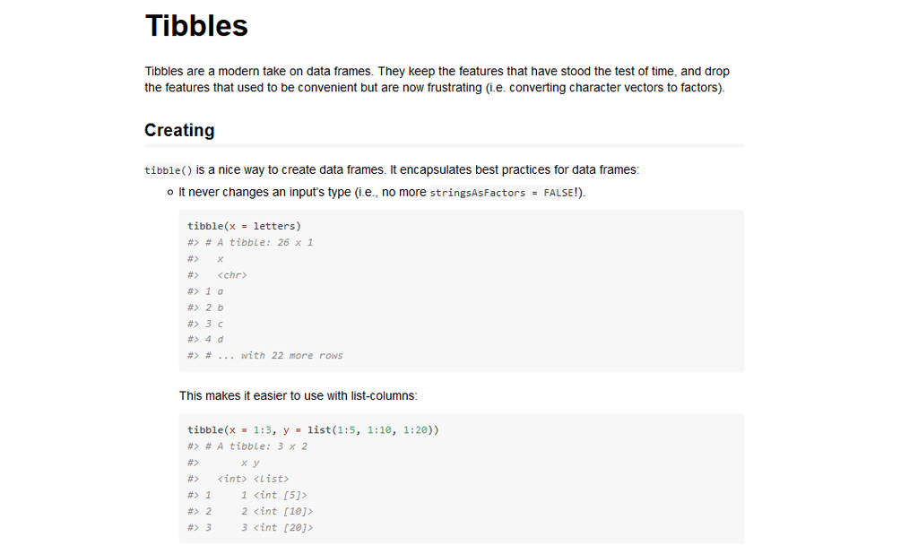

```r
vignette(package = "tibble")
```

## %>%

### *magrittr* : "Ceci n'est pas un pipe."

[figure not shown]

## Pré-requis

```r
library(pryr)
```

```r
library(tidyverse)
```

```r
tidyverse_conflicts()
```

## Qu'est-ce-que le "pipe" ?

L'opérateur "pipe" (`%>%`) provient du package **magrittr** développé par Stefan Milton Bache.

Par défaut `library(tidyverse)` s'occupe de charger l'opérateur "pipe".

**Exemple :**

- `x %>% f` équivalent à `f(x)`
- `x %>% f(y)` équivalent à `f(x, y)`
- `x %>% f %>% g %>% h` équivalent à `h(g(f(x)))`
- `f <- . %>% cos %>% sin` équivalent à `f <- function(.) sin(cos(.))`

## Pourquoi utiliser le "pipe" ?

Une aide à :

- l'écriture du code.
- la lisibilité du code.

Note : Raccourci `Ctrl+M` dans Rstudio pour faire apparaître un "pipe".

## Conserver les étapes

```r
x <- rnorm(25)
x1 <- sqrt(x)
x2 <- na.exclude(x1)
x3 <- x2<1
x4 <- table(x3)
x5 <- prop.table(x4)
x6 <- which.max(x5)
x7 <- names(x6)
```

Les inconvénients de cette écriture :

- Obligation de nommer de façon explicite les différents objets.
- Environnement surchargé d'objets peu utiles (`ls()`).
- Utilisation plus importante de la mémoire vive ?

  ```r
  mtcars2 <- mtcars %>% mutate(cyl_fac = factor(cyl))

  pryr::object_size(mtcars)
  pryr::object_size(mtcars2)
  pryr::object_size(mtcars, mtcars2)
  ```

## Remplacer l'objet original

```r
x <- rnorm(25)

x <- sqrt(x)
x <- na.exclude(x)
x <- x<1
x <- table(x)
x <- prop.table(x)
x <- which.max(x)
x <- names(x)
```

## Composer l'appel aux fonctions

```r
x <- rnorm(25)

names(
  which.max(
    prop.table(
      table(
        na.exclude(
          sqrt(x)
        )<1
      )
    )
  )
)

names(which.max(prop.table(table(na.exclude(sqrt(x))<1))))
```

Les inconvénients de cette écriture :

- L'ordre des appels va de l'intérieur vers l'extérieur.
- Les arguments peuvent se situés "loin" de la fonction.

## Utiliser le "pipe"

```r
x %>%
  sqrt() %>%
  na.exclude() %>%
  `<`(1) %>%
  table() %>%
  prop.table() %>%
  which.max() %>%
  names()
```

A éviter si :

- le nombre d'étapes devient important.  
  Utiliser des objets intermédiaires avec des noms claires.
- la séquence d'opération n'est pas linéaire.
- les opérations nécéssitent plusieurs objets en entrée et/ou sortie.

## Pour aller plus loin …

[figure not shown]

```r
vignette(package = "magrittr")
```

## *readr* & *readxl*

### Importer des données

[figure not shown]

## Pré-requis

```r
library(readxl)
```

```r
library(tidyverse)
```

```r
tidyverse_conflicts()
```

## Les fonctions de base de *readr*

Lire des tableaux rectangulaires :

- `read_csv()` : fichier avec séparateur virgule (".csv").
- `read_tsv()` : fichier avec séparateur tabulation.
- `read_table()` : fichier avec séparateur espace.
- `read_delim()` : forme générale (`delim = ""`).

Lire des données R (".rds") :

- `read_rds()` : surcouche de `readRDS()` (sans compression).

Lire des formats plus exotiques :

- `read_fwf()` : fichier à largeur fixe (nombre de caractères).
- `read_log()` : fichier de log provenant de serveur web Apache.

## Par rapport à celles de R : Entrée

```r
locale()
```

```
#> <locale>
#> Numbers:  123,456.78
#> Formats:  %AD / %AT
#> Timezone: UTC
#> Encoding: UTF-8
#> <date_names>
#> Days:   Sunday (Sun), Monday (Mon), Tuesday (Tue), Wednesday (Wed), Thursday
#>         (Thu), Friday (Fri), Saturday (Sat)
#> Months: January (Jan), February (Feb), March (Mar), April (Apr), May (May),
#>         June (Jun), July (Jul), August (Aug), September (Sep), October
#>         (Oct), November (Nov), December (Dec)
#> AM/PM:  AM/PM
```

## Par rapport à celles de R : Sortie

- Conversion des champs "date" au format `"%Y-%m-%d"`.
- Conversion des champs date/heure dans la norme ISO8601.  
  Par exemple :
  - 07:57:59Z
  - 2018-04-13T07:57:59Z
- Noms des colonnes inchangés.
- Renvoie un objet *tibble*.
- Pas de nom de ligne.

## Dans la pratique

### Lire un CSV avec *base*

```r
ratings <- read.csv(
  file = "./materials/ratings.csv"
)
str(ratings[0, ])
```

```
#> 'data.frame':    0 obs. of  13 variables:
#>  $ Const         : chr
#>  $ Your.Rating   : int
#>  $ Date.Rated    : chr
#>  $ Title         : chr
#>  $ URL           : chr
#>  $ Title.Type    : chr
#>  $ IMDb.Rating   : num
#>  $ Runtime..mins.: int
#>  $ Year          : int
#>  $ Genres        : chr
#>  $ Num.Votes     : int
#>  $ Release.Date  : chr
#>  $ Directors     : chr
```

## Dans la pratique

### Lire un CSV avec *readr*

```r
ratings <- read_csv(
  file = "./materials/ratings.csv"
)
```

## Dans la pratique

### Lire un "texte" avec *base*

```r
read.csv(
  text = "a,b,c
    1,2,3
    4,5,6"
)
```

```
#>   a b c
#> 1 1 2 3
#> 2 4 5 6
```

## Dans la pratique

### Lire un "texte" avec *readr*

```r
read_csv(
  "a,b,c
  1,2,3
  4,5,6"
)
```

```
#> # A tibble: 2 x 3
#>       a     b     c
#>   <int> <int> <int>
#> 1     1     2     3
#> 2     4     5     6
```

## Les arguments de *readr*

- L'argument `skip = n`

  ```r
  read_csv("Une ligne de métadonnées
    x,y,z
    1,2,3", skip = 1)
  ```

  ```
  #> # A tibble: 1 x 3
  #>       x     y     z
  #>   <int> <int> <int>
  #> 1     1     2     3
  ```

- L'argument `comment = "#"`

  ```r
  read_csv("# Une ligne de commentaires
    x,y,z
    1,2,3", comment = "#")
  ```

  ```
  #> # A tibble: 1 x 3
  #>       x     y     z
  #>   <int> <int> <int>
  #> 1     1     2     3
  ```

## Les arguments de *readr*

- L'argument `col_names = FALSE`

  ```r
  read_csv("1,2,3\n4,5,6", col_names = FALSE)
  ```

  ```
  #> # A tibble: 2 x 3
  #>      X1    X2    X3
  #>   <int> <int> <int>
  #> 1     1     2     3
  #> 2     4     5     6
  ```

- Utiliser `col_names`pour nommer les colonnes

  ```r
  read_csv("1,2,3\n4,5,6", col_names = c("a", "b", "c"))
  ```

  ```
  #> # A tibble: 2 x 3
  #>       a     b     c
  #>   <int> <int> <int>
  #> 1     1     2     3
  #> 2     4     5     6
  ```

## Les arguments de *readr*

- L'argument `na = "."`

  ```r
  read_csv("a,b,c\n1,2,3\n4,.,6", na = ".")
  ```

  ```
  #> # A tibble: 2 x 3
  #>       a     b     c
  #>   <int> <int> <int>
  #> 1     1     2     3
  #> 2     4    NA     6
  ```

- L'argument `col_types`

  ```r
  read_csv(
    "a,b,c\n1,x,2018-05-03\n4,y,2018-05-04",
    col_types = list(col_integer(), col_character(), col_date(format = "%Y-%m-%d"))
  )
  ```

  ```
  #> # A tibble: 2 x 3
  #>       a b     c
  #>   <int> <chr> <date>
  #> 1     1 x     2018-05-03
  #> 2     4 y     2018-05-04
  ```

## Exercices

- Quelle fonction utiliseriez-vous pour importer un document avec `|` en séparateur ?
- Un fichier CSV peut parfois contenir une virgule dans un champ.  
  Astuce : utilisez des guillemets simple `'` ou double `"`.
  1. Quel est le caractère par défaut utiliser par `read_csv()` ?
  2. Quelle fonction et argument utiliser pour changer ce caractère ?
  3. Quelle fonction et avec quel valeur argument liriez-vous la chaîne suivante ?

  ```r
  "x,y\n1,'a,b'"
  ```

- Identifier les problèmes des lignes suivantes.

  ```r
  read_csv("a,b\n1,2,3\n4,5,6")
  read_csv("a,b,c\n1,2\n1,2,3,4")
  read_csv("a,b\n\"1")
  read_csv("a,b\n1,2\na,b")
  read_csv("a;b\n1;3")
  ```

## Les alternatives à *readr*

| Type de données | Package | Alternatives |
| --- | --- | --- |
| Fichier "Texte" | *readr* | base, data.table |
| Excel | *readxl* | gdata, openxlsx, XLConnect, xlsx |
| Logiciel Statistique | *haven* | foreign, sas7bdat, readstata13 |

## Quelques benchmark !

[figure not shown]

## Quelques benchmark : Lecture

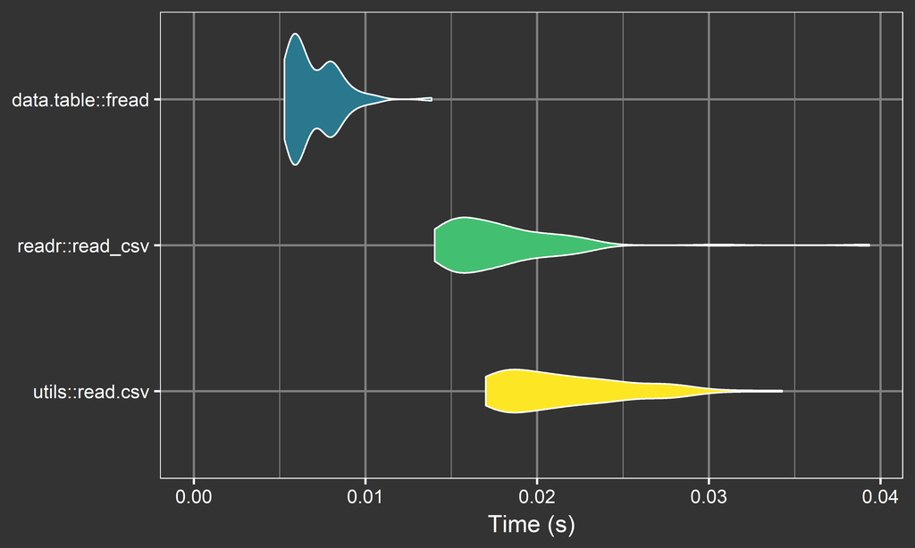

## Quelques benchmark : Ecriture

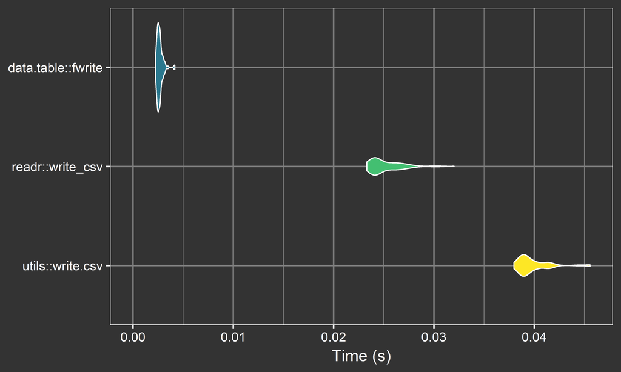

## Exporter des données vers un fichier

*readr* inclut également des fonctions d'écriture `write_*()`.

- Les chaînes de caractères sont en UTF-8.

[figure not shown]

- Les dates et date/heure sont au format ISO8601

**Exemple** :

```r
readr::write_csv(x = ratings, path = "ratings.csv")
```

```r
writexl::write_xlsx(x = ratings, path = "ratings.xlsx")
```

## *dplyr*

### Une grammaire de la manipulation des données

## *dplyr* : Le pipe et des fonctions utiles

[figure not shown]

## Pré-requis

```r
library(tidyverse)
```

```r
tidyverse_conflicts()
```

## Les fonctions de base

5 (+1) fonctions clés de *dplyr* :

1. Sélectionner des observations par valeur (`filter()`).
2. Trier les lignes (`arrange()`).
3. Sélectionner des colonnes (`select()`).
4. Ajouter des colonnes en fonction des colonnes préexistantes (`mutate()`).
5. Résumer des valeurs (`summarise()`).
6. `group_by()` pour travailler sur des sous-ensembles d'un jeu de données.

## Les fonctions de base

Une syntaxe commune :

- le premier argument est un objet `data.frame`.
- Le second argument décrit l'action à effectuer (noms de variable sans guillemets).
- Renvoie un `data.frame` (ou `tibble`).

## Sélectionner des lignes

```r
ratings <- read_csv(file = "./materials/ratings.csv")
```

```r
filter(ratings, `Your Rating` >= 9, `IMDb Rating` >= 9)
```

```
#> # A tibble: 1 x 13
#>   Const  `Your Rating` `Date Rated` Title   URL      `Title Type` `IMDb Rating`
#>   <chr>          <int> <date>       <chr>   <chr>    <chr>                <dbl>
#> 1 tt011~             9 2014-11-08   The Sh~ https:/~ movie                 9.30
#> # ... with 6 more variables: `Runtime (mins)` <int>, Year <int>, Genres <chr>,
#> #   `Num Votes` <int>, `Release Date` <date>, Directors <chr>
```

```r
read_csv(file = "./materials/ratings.csv") %>%
  filter(`Your Rating` >= 9 & `IMDb Rating` >= 9)
```

```
#> # A tibble: 1 x 13
#>   Const  `Your Rating` `Date Rated` Title   URL      `Title Type` `IMDb Rating`
#>   <chr>          <int> <date>       <chr>   <chr>    <chr>                <dbl>
#> 1 tt011~             9 2014-11-08   The Sh~ https:/~ movie                 9.30
#> # ... with 6 more variables: `Runtime (mins)` <int>, Year <int>, Genres <chr>,
#> #   `Num Votes` <int>, `Release Date` <date>, Directors <chr>
```

## Exercices

## Réordonner des lignes

```r
read_csv(file = "./materials/ratings.csv") %>%
  arrange(desc(`Date Rated`))
```

```
#> # A tibble: 2,229 x 13
#>    Const  `Your Rating` `Date Rated` Title  URL      `Title Type` `IMDb Rating`
#>    <chr>          <int> <date>       <chr>  <chr>    <chr>                <dbl>
#>  1 tt723~             2 2018-04-13   Taxi 5 https:/~ movie                 5.60
#>  2 tt331~             2 2018-04-08   Game ~ https:/~ movie                 5.40
#>  3 tt509~             5 2018-04-08   Dans ~ https:/~ movie                 6.20
#>  4 tt287~             5 2018-04-05   Red S~ https:/~ movie                 6.80
#>  5 tt699~             2 2018-04-04   Gasto~ https:/~ movie                 3.90
#>  6 tt536~             5 2018-03-31   Mary ~ https:/~ movie                 6.00
#>  7 tt167~             6 2018-03-28   Ready~ https:/~ movie                 7.90
#>  8 tt678~             3 2018-03-28   Dolph~ https:/~ movie                 6.40
#>  9 tt641~             2 2018-03-24   Eva    https:/~ movie                 4.90
#> 10 tt714~             5 2018-03-24   La fi~ https:/~ movie                 6.20
#> # ... with 2,219 more rows, and 6 more variables: `Runtime (mins)` <int>,
#> #   Year <int>, Genres <chr>, `Num Votes` <int>, `Release Date` <date>,
#> #   Directors <chr>
```

## Exercices

## Sélectionner des colonnes

Des aides à la sélection :

- `starts_with("abc")` : noms commençant par "abc".
- `ends_with("xyz")` : noms finissant par "xyz".
- `contains("ijk")` : noms contenant "ijk".
- `matches("(.)\\1")` : noms correspondant à l'expression régulière.
- `num_range("x", 1:3)`: noms correspondant à `x1`, `x2` et `x3`.

```r
read_csv(file = "./materials/ratings.csv") %>%
  arrange(desc(`Date Rated`)) %>%
  select(Title, ends_with("Rating"))
```

```
#> # A tibble: 2,229 x 3
#>   Title           `Your Rating` `IMDb Rating`
#>   <chr>                   <int>         <dbl>
#> 1 Taxi 5                      2          5.60
#> 2 Game Over, Man!             2          5.40
#> 3 Dans la brume               5          6.20
#> 4 Red Sparrow                 5          6.80
#> # ... with 2,225 more rows
```

## Exercices

## Ajouter des colonnes

```r
read_csv(file = "./materials/ratings.csv") %>%
  arrange(desc(`Date Rated`)) %>%
  mutate(Rating_is_better = `Your Rating`>=`IMDb Rating`) %>%
  select(Title, `Your Rating`, `IMDb Rating`, Rating_is_better)
```

```
#> # A tibble: 2,229 x 4
#>    Title            `Your Rating` `IMDb Rating` Rating_is_better
#>    <chr>                    <int>         <dbl> <lgl>
#>  1 Taxi 5                       2          5.60 F
#>  2 Game Over, Man!              2          5.40 F
#>  3 Dans la brume                5          6.20 F
#>  4 Red Sparrow                  5          6.80 F
#>  5 Gaston Lagaffe               2          3.90 F
#>  6 Mary Magdalene               5          6.00 F
#>  7 Ready Player One             6          7.90 F
#>  8 Dolphins                     3          6.40 F
#>  9 Eva                          2          4.90 F
#> 10 La finale                    5          6.20 F
#> # ... with 2,219 more rows
```

## Exercices

## Résumer les données

```r
read_csv(file = "./materials/ratings.csv") %>%
  summarise(
    n_movies = n(),
    my_average_rating = mean(`Your Rating`),
    users_average_rating = mean(`IMDb Rating`),
    oldest_rating = min(`Date Rated`),
    newest_rating =  max(`Date Rated`)
  )
```

```
#> # A tibble: 1 x 5
#>   n_movies my_average_rating users_average_rating oldest_rating newest_rating
#>      <int>             <dbl>                <dbl> <date>        <date>
#> 1     2229              5.60                 6.44 2014-11-08    2018-04-13
```

## Exercices

## Utiliser `group_by()`

```r
read_csv(file = "./materials/ratings.csv") %>%
  mutate(
    Year = lubridate::year(`Date Rated`)
  ) %>%
  filter(Year!="2014") %>%
  group_by(Year) %>%
  summarise(
    n_movies = n(),
    my_average_rating = mean(`Your Rating`),
    users_average_rating = mean(`IMDb Rating`)
  ) %>%
  arrange(desc(Year))
```

```
#> # A tibble: 4 x 4
#>    Year n_movies my_average_rating users_average_rating
#>   <dbl>    <int>             <dbl>                <dbl>
#> 1  2018       52              4.98                 6.42
#> 2  2017      204              5.12                 6.44
#> 3  2016      238              5.13                 6.48
#> 4  2015      374              5.07                 6.19
```

## Exercices

## Pour aller plus loin …

- Cheatsheets Rstudio : https://www.rstudio.com/resources/cheatsheets/
- Site de dplyr : [dplyr.tidyverse.org](https://dplyr.tidyverse.org/)

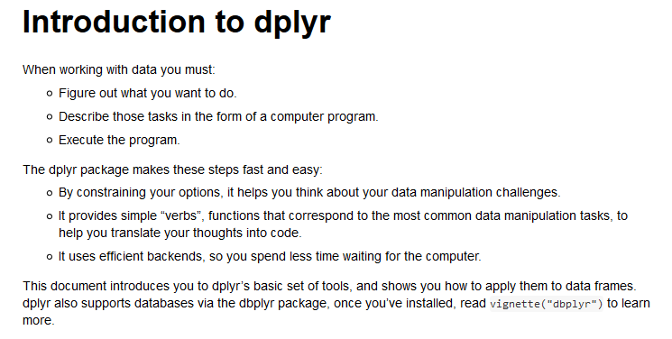

```r
vignette(package = "dplyr")
```

## *DBI*

### Importer depuis une base de données

## Pré-requis

```r
library(DBI)
```

```r
library(odbc)
```

```r
tidyverse_conflicts()
```

## Démarrer PostgreSQL

- Lancez PostgreSQL via le raccourci "SQL Shell (psql)".
- Laissez les valeurs par défaut (pressez "Entrée").

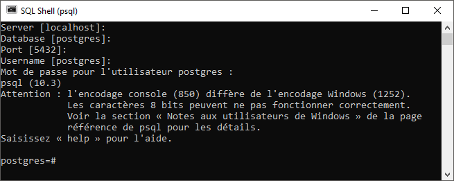

## Démarrer PostgreSQL

Pour retirer le message d'avertissement, ajouter "chcp 1252" dans le fichier ".bat".

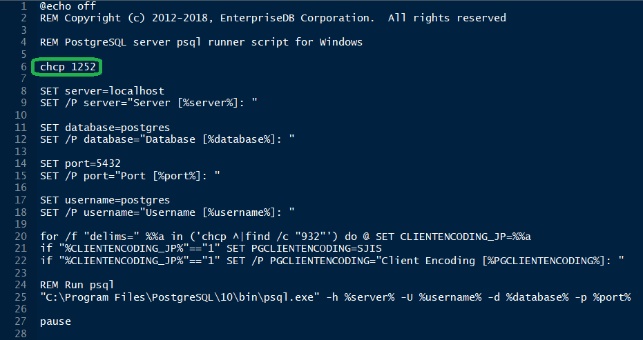

## Commandes psql

- `\?` pour l'aide des commandes psql.
- `\q` quitter.
- `\h` aide des commandes sql.
- `\l` liste des bases de données.
- `\c` se connecter à une base.
- `\d` [nom] pour la description d'une table, d'un index, séquence, vue.
- `\d` liste des relations (tables, vues et séquences).
- `\i` nom_fichier.sql exécuter un fichier de commandes SQL.

## Base, utilisateur et droits en SQL

- Créer un utilisateur.

  ```sql
  CREATE ROLE rdb LOGIN password 'rdbpass';
  ```

- Créer une base.

  ```sql
  CREATE DATABASE datawarehouse;
  ```

- Modifier le propriètaire d'une base.

  ```sql
  ALTER DATABASE datawarehouse OWNER TO 'rdb';
  ```

## Base, utilisateur et droits en R

Des connecteurs :

- [RMySQL](https://github.com/rstats-db/RMySQL#readme): MySQL et MariaDB.
- RPostgreSQL: Postgres et Redshift.
- RSQLite: base de donnée SQLite intégrée.
- odbc: protocoles de connection libre.
- bigrquery: Google BigQuery.

## Base, utilisateur et droits en R

- Identifier le driver de connection.

```r
odbcListDrivers() %>%
  filter(attribute=="DriverODBCVer") %>%
  select(-attribute)
```

```
#>                                                     name      value
#> 1                                             SQL Server      03.50
#> 2               Microsoft Access Driver (*.mdb, *.accdb)      02.50
#> 3 Microsoft Excel Driver (*.xls, *.xlsx, *.xlsm, *.xlsb)      02.50
#> 4            Microsoft Access Text Driver (*.txt, *.csv)      02.50
#> 5                           PostgreSQL ODBC Driver(ANSI) 10.01.0000
#> 6                        PostgreSQL ODBC Driver(UNICODE) 10.01.0000
```

## Base, utilisateur et droits en R

- Initier la connection.

```r
con <- dbConnect(
  drv = odbc(),
  driver = "PostgreSQL ODBC Driver(UNICODE)",
  server = "localhost",
  port = 5432,
  database = "postgres",
  uid = "postgres",
  password = "password"
)
```

```r
con <- dbConnect(
  drv = odbc(),
  driver = "PostgreSQL ODBC Driver(UNICODE)",
  server = "localhost",
  port = 5432,
  database = "postgres",
  uid = "postgres",
  password = rstudioapi::askForPassword("Mot de passe :")
)
```

## Base, utilisateur et droits en R

- Créer un utilisateur.

  ```r
  dbSendQuery(con, SQL("CREATE ROLE rdb LOGIN password 'rdbpass';"))
  ```

  ```
  #> <OdbcResult>
  #>   SQL  CREATE ROLE rdb LOGIN password 'rdbpass';
  #>   ROWS Fetched: 0 [complete]
  #>        Changed: 71285632
  ```

- Créer une base.

  ```r
  dbSendQuery(con, SQL("CREATE DATABASE datawarehouse;"))
  ```

  ```
  #> <OdbcResult>
  #>   SQL  CREATE DATABASE datawarehouse;
  #>   ROWS Fetched: 0 [complete]
  #>        Changed: 71285632
  ```

## Base, utilisateur et droits en R

- Modifier le propriètaire d'une base.

  ```r
  dbSendQuery(con, SQL("ALTER DATABASE datawarehouse OWNER TO rdb;"))
  ```

  ```
  #> <OdbcResult>
  #>   SQL  ALTER DATABASE datawarehouse OWNER TO rdb;
  #>   ROWS Fetched: 0 [complete]
  #>        Changed: 71285632
  ```

- Se déconnecter de la base.

  ```r
  dbDisconnect(con)
  ```

## Créer des tables en SQL depuis R

- Se connecter en tant que "rdb".

  ```r
  con <- dbConnect(
    drv = odbc(),
    driver = "PostgreSQL ODBC Driver(UNICODE)",
    server = "localhost",
    database = "datawarehouse",
    port = 5432,
    uid = "rdb",
    password = "rdbpass"
  )
  ```

## Créer des tables en SQL depuis R

- Lister les tables.

  ```r
  dbListTables(con)
  ```

  ```
  #> character(0)
  ```

- Créer la table *mtcars*.

  ```r
  mtcars %>%
    rownames_to_column(var = "car") %>%
    mutate(const = gsub(" .*", "", car)) %>%
    select(const, everything()) %>%
    dbWriteTable(con, "mtcars", .)
  ```

- Lister les tables.

  ```r
  dbListTables(con)
  ```

  ```
  #> [1] "mtcars"
  ```

## Faire des requêtes en SQL depuis R

- Lister les champs d'une table.

  ```r
  dbListFields(con, "mtcars")
  ```

  ```
  #>  [1] "const" "car"   "mpg"   "cyl"   "disp"  "hp"    "drat"  "wt"    "qsec"
  #> [10] "vs"    "am"    "gear"  "carb"
  ```

- Lire une table.

  ```r
  dbReadTable(con, "mtcars") %>%
    as_tibble()
  ```

  ```
  #> # A tibble: 32 x 13
  #>   const car     mpg   cyl  disp    hp  drat    wt  qsec    vs    am  gear  carb
  #>   <chr> <chr> <dbl> <dbl> <dbl> <dbl> <dbl> <dbl> <dbl> <dbl> <dbl> <dbl> <dbl>
  #> 1 Mazda Mazd~  21.0  6.00   160 110    3.90  2.62  16.5  0     1.00  4.00  4.00
  #> 2 Mazda Mazd~  21.0  6.00   160 110    3.90  2.88  17.0  0     1.00  4.00  4.00
  #> 3 Dats~ Dats~  22.8  4.00   108  93.0  3.85  2.32  18.6  1.00  1.00  4.00  1.00
  #> 4 Horn~ Horn~  21.4  6.00   258 110    3.08  3.22  19.4  1.00  0     3.00  1.00
  #> 5 Horn~ Horn~  18.7  8.00   360 175    3.15  3.44  17.0  0     0     3.00  2.00
  #> # ... with 27 more rows
  ```

## Faire des requêtes en SQL depuis R

- Sélectioner les voitures du constructeur Mercedes.

  ```r
  res <- dbSendQuery(con, "SELECT * FROM mtcars WHERE const='Merc'")
  dbFetch(res)
  ```

  ```
  #>   const         car  mpg cyl  disp  hp drat   wt qsec vs am gear carb
  #> 1  Merc   Merc 240D 24.4   4 146.7  62 3.69 3.19 20.0  1  0    4    2
  #> 2  Merc    Merc 230 22.8   4 140.8  95 3.92 3.15 22.9  1  0    4    2
  #> 3  Merc    Merc 280 19.2   6 167.6 123 3.92 3.44 18.3  1  0    4    4
  #> 4  Merc   Merc 280C 17.8   6 167.6 123 3.92 3.44 18.9  1  0    4    4
  #> 5  Merc  Merc 450SE 16.4   8 275.8 180 3.07 4.07 17.4  0  0    3    3
  #> 6  Merc  Merc 450SL 17.3   8 275.8 180 3.07 3.73 17.6  0  0    3    3
  #> 7  Merc Merc 450SLC 15.2   8 275.8 180 3.07 3.78 18.0  0  0    3    3
  ```

- Libérer les ressources occupées par la requête.

  ```r
  dbClearResult(res)
  dbDisconnect(con)
  ```

## Exercices

- En tant qu'utilisateur "postgres", créez une base "movies".  
  Faire de "imdb_user" le propriètaire de cette base.

  ```r
  con <- dbConnect(
    drv = odbc(),
    driver = "PostgreSQL ODBC Driver(UNICODE)",
    server = "localhost",
    database = "datawarehouse",
    port = 5432,
    uid = "postgres",
    password = "password"
  )
  dbSendQuery(con, SQL("CREATE ROLE imdb_user LOGIN password 'password';"))
  dbSendQuery(con, SQL("CREATE DATABASE movies;"))
  dbSendQuery(con, SQL("ALTER DATABASE Movies OWNER TO imdb_user;"))
  dbDisconnect(con)
  ```

## Exercices

- En tant qu'utilisateur "imdb_user", exportez le fichier "ratings.csv" vers la base. Enlevez les espaces dans les noms de colonnes.

  ```r
  ratings <- read_csv(file = "./materials/ratings.csv") %>%
    `colnames<-`(gsub(" ", "", colnames(.)))
  ```

  ```r
  con <- dbConnect(
    drv = odbc(),
    driver = "PostgreSQL ODBC Driver(UNICODE)",
    server = "localhost",
    database = "movies",
    port = 5432,
    uid = "imdb_user",
    password = "password"
  )
  dbWriteTable(con, "ratings", ratings)
  ```

## Exercices

- Listez les noms de colonnes de la table créée.

  ```r
  dbListFields(con, 'ratings')
  ```

## Exercices

- Utilisez une requête SQL pour compter le nombre de films pour chaque note (`"YourRating"`).  
  Importer le résultat localement sous la forme d'un *tibble*.

  ```r
  dbSendQuery(
    conn = con,
    statement = SQL(
      'SELECT "YourRating", COUNT(*) as count FROM ratings GROUP BY "YourRating";'
    )
  ) %>%
    dbFetch() %>%
    as_tibble()
  ```

## Exercices

- Sélectionnez les films notés entre le 1er janvier 2017 et le 31 décembre 2017.  
  Exportez cette table vers la base de données.

  ```r
  dbSendQuery(
    conn = con,
    statement = SQL(
      'SELECT *
        FROM ratings
        WHERE "DateRated">=\'2017-01-01\' AND "DateRated"<=\'2017-12-31\';'
    )
  ) %>%
    dbFetch()%>%
    dbWriteTable(con, "ratings2017", .)

  dbListTables(con)
  ```

## Pour aller plus loin …

Liste de diffusion autour du package *DBI*: r-sig-db.

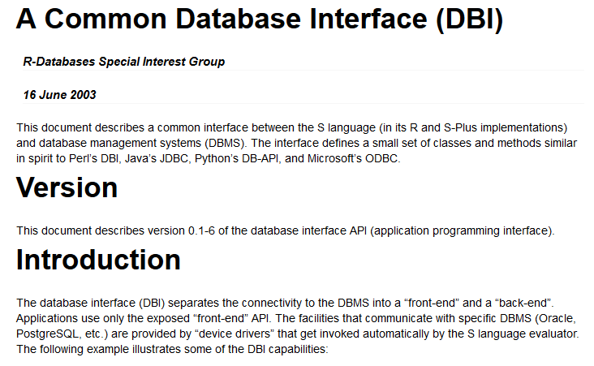

```r
vignette(package = "DBI")
```

## *dplyr* & *dbplyr*

### Une grammaire SQL généralisée

## Pré-requis

```r
library(DBI)
```

```r
library(odbc)
```

```r
library(tidyverse)
```

```r
library(dbplyr)
```

```r
tidyverse_conflicts()
```

## *dbplyr* : Premiers pas avec *dplyr*

- Connection sur une base de donnée SQL intégrée (package *RSQLite*).

  ```r
  con <- dbConnect(RSQLite::SQLite(), path = ":memory:")
  ```

- Connection à la base PostgreSQL.

  ```r
  con <- dbConnect(
    drv = odbc(),
    driver = "PostgreSQL ODBC Driver(UNICODE)",
    server = "localhost",
    database = "movies",
    port = 5432,
    uid = "imdb_user",
    password = "password"
  )
  ```

## *dbplyr* : Premiers pas avec *dplyr*

- Remplir la base.

  ```r
  ratings <- read_csv(file = "./materials/ratings.csv") %>%
    `colnames<-`(gsub(" ", "", colnames(.))) %>%
    mutate(Year = lubridate::year(DateRated))
  ```

  ```r
  copy_to(
    dest = con,
    df = ratings,
    name = "ratings_idx",
    temporary = FALSE,
    indexes = list(
      "DateRated",
      "YourRating",
      "Title",
      "Year"
    ),
    overwrite = TRUE
  )
  ```

Note : `temporary = TRUE` permet de rendre la table uniquement disponible à la connection en cours et uniquement pendant celle-ci.

## *dbplyr* : Premiers pas avec *dplyr*

- Faire une référence à une table depuis une connection.

  ```r
  ratings_db <- tbl(con, "ratings")
  class(ratings_db)
  ```

  ```
  #> [1] "tbl_dbi"  "tbl_sql"  "tbl_lazy" "tbl"
  ```

- Afficher l'objet.

  ```r
  ratings_db
  ```

  ```
  #> # Source:   table<ratings> [?? x 13]
  #> # Database: postgres [imdb_user@localhost:/movies]
  #>   Const  YourRating DateRated  Title URL   TitleType IMDbRating `Runtime(mins)`
  #>   <chr>       <int> <date>     <chr> <chr> <chr>          <dbl>           <int>
  #> 1 tt100~          5 2014-12-17 He's~ http~ movie           6.40             129
  #> 2 tt100~          7 2014-11-08 Mega~ http~ movie           7.30              95
  #> 3 tt010~          3 2014-11-26 The ~ http~ movie           5.10              90
  #> 4 tt100~          7 2014-12-26 Ca$h  http~ movie           6.00             100
  #> # ... with more rows, and 5 more variables: Year <int>, Genres <chr>,
  #> #   NumVotes <int>, ReleaseDate <date>, Directors <chr>
  ```

## Manipuler une base avec *dplyr*

- Faire des requêtes sans SQL.

```r
date_sevendaysago <- (Sys.Date()-7)

ratings_db %>%
  filter(DateRated > date_sevendaysago) %>%
  select(Title, DateRated, YourRating, IMDbRating)
```

```
#> # Source:   lazy query [?? x 4]
#> # Database: postgres [imdb_user@localhost:/movies]
#>   Title  DateRated  YourRating IMDbRating
#>   <chr>  <date>          <int>      <dbl>
#> 1 Taxi 5 2018-04-13          2       5.60
```

## Manipuler une base avec *dplyr*

- Faire des opérations en SQL sans SQL.

```r
ratings_db %>%
  group_by(Year) %>%
  summarise(
    N = n(),
    AvgRating = mean(YourRating)
  ) %>%
  arrange(Year)
```

```
#> # Source:     lazy query [?? x 3]
#> # Database:   postgres [imdb_user@localhost:/movies]
#> # Ordered by: Year
#>    Year N               AvgRating
#>   <int> <S3: integer64>     <dbl>
#> 1  1936 1                    8.00
#> 2  1937 1                    7.00
#> 3  1940 1                    7.00
#> 4  1941 1                    7.00
#> # ... with more rows
```

## Manipuler une base avec *dplyr*

- *dplyr* et *tbl_df*.

  ```r
  ratings_summary <- ratings %>%
    group_by(Year) %>%
    summarise(
      N = n(),
      AvgRating = mean(YourRating)
    ) %>%
    arrange(Year)
  ```

  ```r
  str(ratings_summary, 1)
  ```

  ```
  #> Classes 'tbl_df', 'tbl' and 'data.frame':    5 obs. of  3 variables:
  #>  $ Year     : num  2014 2015 2016 2017 2018
  #>  $ N        : int  1361 374 238 204 52
  #>  $ AvgRating: num  5.93 5.07 5.13 5.12 4.98
  ```

## Manipuler une base avec *dplyr*

- *dplyr* et *tbl_sql*.

  ```r
  ratings_summary_db <- ratings_db %>%
    group_by(Year) %>%
    summarise(
      N = n(),
      AvgRating = mean(YourRating)
    ) %>%
    arrange(Year)
  ```

  ```r
  str(ratings_summary_db, 1)
  ```

  ```
  #> List of 2
  #>  $ src:List of 2
  #>   ..- attr(*, "class")= chr [1:3] "src_dbi" "src_sql" "src"
  #>  $ ops:List of 4
  #>   ..- attr(*, "class")= chr [1:3] "op_arrange" "op_single" "op"
  #>  - attr(*, "class")= chr [1:4] "tbl_dbi" "tbl_sql" "tbl_lazy" "tbl"
  ```

## Manipuler une base avec *dplyr*

- L'envoi de la requête ne s'effectue qu'à la fin ou à l'affichage de l'objet.

  ```r
  ratings_summary_db %>%
    print()
  ```

  ```
  #> # Source:     lazy query [?? x 3]
  #> # Database:   postgres [imdb_user@localhost:/movies]
  #> # Ordered by: Year
  #>    Year N               AvgRating
  #>   <int> <S3: integer64>     <dbl>
  #> 1  1936 1                    8.00
  #> 2  1937 1                    7.00
  #> 3  1940 1                    7.00
  #> 4  1941 1                    7.00
  #> # ... with more rows
  ```

## Manipuler une base avec *dplyr*

- Les données ne sont jamais téléchargées dans la session R (sauf mention explicite).

  ```r
  ratings_summary_db %>%
    collect()
  ```

  ```
  #> # A tibble: 66 x 3
  #>    Year N               AvgRating
  #>   <int> <S3: integer64>     <dbl>
  #> 1  1936 1                    8.00
  #> 2  1937 1                    7.00
  #> 3  1940 1                    7.00
  #> 4  1941 1                    7.00
  #> # ... with 62 more rows
  ```

## Retour au SQL avec *dplyr*

- Que fait *dplyr* pour effectuer la commande précédente `ratings_summary_db` ?

  ```r
   ratings_summary_db %>%
    show_query()
  ```

  ```
  #> <SQL>
  #> SELECT "Year", COUNT(*) AS "N", AVG("YourRating") AS "AvgRating"
  #> FROM "ratings"
  #> GROUP BY "Year"
  #> ORDER BY "Year"
  ```

- Traduire du R en requête SQL.

```r
translate_sql(head(ratings_db))
```

```
#> <SQL> HEAD("ratings_db")
```

## Exercices

- Comment *dbplyr* traduit les fonctions `as.numeric()` et `as.character()` ?
- Comment *dbplyr* traduit l'opérateur `^` ?
- Comment *dbplyr* traduit les fonctions `mean()`et `sd()` ?  
  Et avec`na.rm = TRUE` ?

## Exercices

- Comment *dbplyr* traduit les fonctions `as.numeric()` et `as.character()` ?

  ```r
  translate_sql(as.numeric(x))
  ```

  ```
  #> <SQL> CAST("x" AS NUMERIC)
  ```

  ```r
  translate_sql(as.character(x))
  ```

  ```
  #> <SQL> CAST("x" AS TEXT)
  ```

## Exercices

- Comment *dbplyr* traduit l'opérateur `^` ?

  ```r
  translate_sql(x^2)
  ```

  ```
  #> <SQL> POWER("x", 2.0)
  ```

  ```r
  tbl(con, sql('select 1 as x')) %>%
    mutate(sqr = x^2)
  ```

  ```
  #> # Source:   lazy query [?? x 2]
  #> # Database: postgres [imdb_user@localhost:/movies]
  #>       x   sqr
  #>   <int> <dbl>
  #> 1     1  1.00
  ```

## Exercices

- Comment *dbplyr* traduit les fonctions `mean()`et `sd()` ?  
  Et avec `trim = 0.05` ou `na.rm = TRUE` ?

  ```r
  translate_sql(mean(x))
  ```

  ```
  #> <SQL> avg("x") OVER ()
  ```

  ```r
  translate_sql(mean(x, trim = 0.05))
  ```

  ```
  #> Error in mean(x, trim = 0.05): argument inutilisé (trim = 0.05)
  ```

  ```r
  translate_sql(mean(x, na.rm = TRUE))
  ```

  ```
  #> <SQL> avg("x") OVER ()
  ```

## *dplyr* > SQL > *tbl* ? > `collect()` > *tbl*

- Rappatrier les données d'une requête via `collect()`

  ```r
  ratings_summary <- ratings_summary_db %>%
    collect()
  class(ratings_summary)
  ```

  ```
  #> [1] "tbl_df"     "tbl"        "data.frame"
  ```

## *dplyr* > SQL > *tbl* ? > `collect()` > *tbl*

- Connaître les dimmensions de l'objet avant `collect()` ?

  ```r
  tally(ratings_summary_db)
  ```

  ```
  #> # Source:   lazy query [?? x 1]
  #> # Database: postgres [imdb_user@localhost:/movies]
  #>   n
  #>   <S3: integer64>
  #> 1 66
  ```

## Exercices

- Utilisez les fonctions `head()` , `tail()` et `nrow()` sur l'une des tables exportées.  
  Que se passe-t'il et pourquoi ?

## Exercices

- Utilisez les fonctions `head()` , `tail()` et `nrow()` sur l'une des tables exportées.  
  Que se passe-t'il et pourquoi ?

  ```r
  ratings_summary_db %>% head(1)
  ```

  ```
  #> # Source:     lazy query [?? x 3]
  #> # Database:   postgres [imdb_user@localhost:/movies]
  #> # Ordered by: Year
  #>    Year N               AvgRating
  #>   <int> <S3: integer64>     <dbl>
  #> 1  1936 1                    8.00
  ```

  ```r
  ratings_summary_db %>% tail()
  ```

  ```
  #> Error: tail() is not supported by sql sources
  ```

  ```r
  ratings_summary_db %>% nrow()
  ```

  ```
  #> [1] NA
  ```

## *dplyr*, `explain()` to me

```r
explain(ratings_summary_db)
```

```
#> <SQL>
#> SELECT "Year", COUNT(*) AS "N", AVG("YourRating") AS "AvgRating"
#> FROM "ratings"
#> GROUP BY "Year"
#> ORDER BY "Year"
```

```
#> <PLAN>
#> Sort  (cost=91.70..92.20 rows=200 width=44)
#>   Sort Key: ratings."Year"
#>   ->  HashAggregate  (cost=79.56..82.06 rows=200 width=44)
#>         Group Key: ratings."Year"
#>         ->  Seq Scan on ratings  (cost=0.00..67.32 rows=1632 width=8)
```

## Exercices (Partie I)

- Connectez vous à la base "datawarehouse" en tant que "rdb".
- Créez une table "mtcars" avec le jeu de données `mtcars`.  
  Comparez les fonctions `dplyr::copy_to()` (en utilisant l'argument `temporary`) et `DBI::dbWriteTable()`.
- Modifiez `mtcars` en passant les noms de lignes dans une colonne et en ajoutant une colonne constructeur `const`.  
  Exporter l'objet `mtcars` vers la base. Que se passe-t'il ? (argument `overwrite`).
- Créez dans la base "datawarehouse" l'ensemble des tables de `nycflights13`.  
  Vérifiez que les tables sont bien créées.
- Effectuez la jointure de `planes`et `flights` pour identifier les 3 constructeurs présentant le plus grand nombre d'heures de vol (`?dplyr::join`).  
  Quelle est la requête SQL réalisée ?

## Exercices (Partie I)

- Connectez vous à la base "datawarehouse" en tant que "rdb".

  ```r
  con <- dbConnect(
    drv = odbc(),
    driver = "PostgreSQL ODBC Driver(UNICODE)",
    server = "localhost",
    database = "datawarehouse",
    port = 5432,
    uid = "rdb",
    password = "rdbpass"
  )
  ```

## Exercices (Partie I)

- Créez une table "mtcars" avec le jeu de données `mtcars`.  
  Comparez les fonctions `dplyr::copy_to()` (en utilisant l'argument `temporary`) et `DBI::dbWriteTable()`.

  ```r
  copy_to(con, mtcars, "mtcars", temporary = TRUE, overwrite = TRUE)
  dbListTables(con)
  ```

  ```
  #> character(0)
  ```

  ```r
  copy_to(con, mtcars, "mtcars", temporary = FALSE, overwrite = TRUE)
  dbListTables(con)
  ```

  ```
  #> [1] "mtcars"
  ```

  ```r
  dbWriteTable(con, "mtcars", mtcars, overwrite = TRUE)
  dbListTables(con)
  ```

  ```
  #> [1] "mtcars"
  ```

## Exercices (Partie I)

- Modifiez `mtcars` en passant les noms de lignes dans une colonne et en ajoutant une colonne constructeur `const`.  
  Exporter l'objet `mtcars` vers la base. Que se passe-t'il ? (argument `overwrite`).

  ```r
  mtcars %>%
    rownames_to_column(var = "car") %>%
    mutate(const = gsub(" .*", "", car)) %>%
    select(const, everything()) %>%
    dbWriteTable(con, "mtcars", ., overwrite = TRUE)
  ```

## Exercices (Partie I)

- Créez dans la base "datawarehouse" l'ensemble des tables de `nycflights13`.  
  Vérifiez que les tables sont bien créées.

  ```r
  library(nycflights13)
  dbWriteTable(con, "flights", flights)
  dbWriteTable(con, "airports", airports)
  dbWriteTable(con, "planes", planes)
  dbWriteTable(con, "weather", weather)
  dbWriteTable(con, "airlines", airlines)

  dbListTables(con)
  ```

## Exercices (Partie I)

- Créez dans la base "datawarehouse" l'ensemble des tables de `nycflights13`.  
  Vérifiez que les tables sont bien créées.

  ```r
  library(nycflights13)
  nycflights13_db <- ls("package:nycflights13") %>%
    lapply(., function(df) {
      copy_to(
        df = get(df),
        dest = con,
        name = df,
        overwrite = TRUE,
        temporary = TRUE
      )
    }) %>%
    `names<-`(ls("package:nycflights13"))
  ```

  ```r
  dbListTables(con)
  ```

  ```
  #> [1] "mtcars"
  ```

## Exercices (Partie I)

- Effectuez la jointure de `planes`et `flights` pour identifier les 3 constructeurs présentant le plus grand nombre d'heures de vol (`?dplyr::join`).

  ```r
  longest_air_time_db <- nycflights13_db[["flights"]] %>%
    inner_join(nycflights13_db[["planes"]], by = "tailnum") %>%
    group_by(manufacturer) %>%
    summarise(total_air_time = sum(air_time)/60) %>%
    arrange(desc(total_air_time)) %>%
    select(manufacturer, total_air_time) %>%
    head(3)
  longest_air_time_db
  ```

  ```
  #> # Source:     lazy query [?? x 2]
  #> # Database:   postgres [rdb@localhost:/datawarehouse]
  #> # Ordered by: desc(total_air_time)
  #>   manufacturer     total_air_time
  #>   <chr>                     <dbl>
  #> 1 BOEING                   296118
  #> 2 AIRBUS                   153993
  #> 3 AIRBUS INDUSTRIE          96442
  ```

## Exercices (Partie I)

- Effectuez la jointure de `planes`et `flights` pour identifier les 3 constructeurs présentant le plus grand nombre d'heures de vol (`?dplyr::join`). Quelle est la requête SQL réalisée ?

  ```r
  longest_air_time_db %>% show_query()
  ```

  ```
  #> <SQL>
  #> SELECT "manufacturer", "total_air_time"
  #> FROM (SELECT *
  #> FROM (SELECT "manufacturer", SUM("air_time") / 60.0 AS "total_air_time"
  #> FROM (SELECT "TBL_LEFT"."year" AS "year.x", "TBL_LEFT"."month" AS "month", "TBL_LEFT"."day" AS "day", "TBL_LEFT"."dep_time" AS "dep_time", "TBL_LEFT"."sched_dep_time" AS "sched_dep_time", "TBL_LEFT"."dep_delay" AS "dep_delay", "TBL_LEFT"."arr_time" AS "arr_time", "TBL_LEFT"."sched_arr_time" AS "s…
  #>   FROM "flights" AS "TBL_LEFT"
  #>   INNER JOIN "planes" AS "TBL_RIGHT"
  #>   ON ("TBL_LEFT"."tailnum" = "TBL_RIGHT"."tailnum")
  #> ) "chmhutivfm"
  #> GROUP BY "manufacturer") "sjmbmhgyxg"
  #> ORDER BY "total_air_time" DESC) "lgsqldsvxc"
  #> LIMIT 3
  ```

## Exercices (Partie II)

- Calculez la moyenne des températures `temp` (table `weather`) par station `origin` et par année `year`.  
  Comparez le résultat entre la version calculée sur l'objet local et sur la base de donnée.
- Comptez le nombre d'aéroport dont le code `dest` (table `flights`) commence par la lettre "A" ([Wildcard SQL](https://www.w3schools.com/sql/sql_wildcards.asp); `%like%`).
- Créez une nouvelle colonne `origin_dest` à partir des colonnes `origin` et `dest`.

## Exercices (Partie II)

- Calculez la moyenne des températures `temp` (table `weather`) par station `origin` et par année `year`.  
  Comparez le résultat entre la version calculée sur l'objet local et sur la base de donnée.

  ```r
  nycflights13::weather %>%
    group_by(origin, year) %>%  summarise(avg_temp = mean(temp))
  ```

  ```
  #> # A tibble: 3 x 3
  #> # Groups:   origin [?]
  #>   origin  year avg_temp
  #>   <chr>  <dbl>    <dbl>
  #> 1 EWR     2013     NA
  #> 2 JFK     2013     54.4
  #> 3 LGA     2013     55.7
  ```

  ```r
  nycflights13_db[["weather"]] %>%
    group_by(origin, year) %>% summarise(avg_temp = mean(temp))
  ```

## Exercices (Partie II)

- Calculez la moyenne des températures `temp` (table `weather`) par station `origin` et par année `year`.  
  Comparez le résultat entre la version calculée sur l'objet local et sur la base de donnée.

  ```r
  nycflights13::weather %>%
    group_by(origin, year) %>%  summarise(avg_temp = mean(temp))
  ```

  ```r
  nycflights13_db[["weather"]] %>%
    group_by(origin, year) %>% summarise(avg_temp = mean(temp))
  ```

  ```
  #> # Source:   lazy query [?? x 3]
  #> # Database: postgres [rdb@localhost:/datawarehouse]
  #> # Groups:   origin
  #>   origin  year avg_temp
  #>   <chr>  <dbl>    <dbl>
  #> 1 JFK     2013     54.4
  #> 2 EWR     2013     55.5
  #> 3 LGA     2013     55.7
  ```

## Exercices (Partie II)

- Comptez le nombre d'aéroport dont le code `dest` (table `flights`) commence par la lettre "A" ([Wildcard SQL](https://www.w3schools.com/sql/sql_wildcards.asp); `%like%`).

  ```r
  nycflights13_db[["flights"]] %>%
    filter(dest %like% 'A%') %>%
    summarise(count = n_distinct(dest))
  ```

  ```
  #> # Source:   lazy query [?? x 1]
  #> # Database: postgres [rdb@localhost:/datawarehouse]
  #>   count
  #>   <S3: integer64>
  #> 1 7
  ```

## Exercices (Partie II)

- Créez une nouvelle colonne `origin_dest` à partir des colonnes `origin` et `dest`.

  ```r
  nycflights13_db[["flights"]] %>%
    mutate(origin_dest = origin %|| '-' ||% dest) %>%
    select(origin, dest, origin_dest)
  ```

  ```
  #> # Source:   lazy query [?? x 3]
  #> # Database: postgres [rdb@localhost:/datawarehouse]
  #>   origin dest  origin_dest
  #>   <chr>  <chr> <chr>
  #> 1 EWR    IAH   EWR-IAH
  #> 2 LGA    IAH   LGA-IAH
  #> 3 JFK    MIA   JFK-MIA
  #> 4 JFK    BQN   JFK-BQN
  #> 5 LGA    ATL   LGA-ATL
  #> # ... with more rows
  ```

## Pour aller plus loin …

- Tutoriel SQL: [www.codecademy.com](https://www.codecademy.com/learn/learn-sql)
- Le SQL en 10 étapes : [blog.jooq.org](https://blog.jooq.org/2016/03/17/10-easy-steps-to-a-complete-understanding-of-sql/)

## *dbplot*

### Du *ggplot2* depuis une base de données

```r
library(DBI)
library(odbc)
library(tidyverse)
library(dbplyr)
library(dbplot)
library(sparklyr)

con <- spark_connect(master = "local")

ratings %>%
  copy_to(con, ., "ratings") %>%
  dbplot_boxplot(x = Year, var = IMDbRating)

dbDisconnect(con)
```

```r
dbDisconnect(con)
con <- dbConnect(
  drv = odbc(),
  driver = "PostgreSQL ODBC Driver(UNICODE)",
  server = "localhost",
  port = 5432,
  database = "postgres",
  uid = "postgres",
  password = "password"
)
dbSendQuery(con, SQL("DROP DATABASE datawarehouse;"))
dbSendQuery(con, SQL("DROP ROLE rdb;"))
dbSendQuery(con, SQL("DROP DATABASE movies;"))
dbSendQuery(con, SQL("DROP ROLE imdb_user;"))
dbDisconnect(con)
# DROP DATABASE datawarehouse; DROP ROLE rdb; DROP DATABASE movies; DROP ROLE imdb_user;
```